# 01 단어 빈도 분석

형태소 분석기를 이용한 단어 빈도 분석

[figure not shown]

## 02-1 형태소 분석

### 띄어쓰기 기준 토큰화의 문제

- 의미를 지니지 않는 서술어가 가장 많이 추출됨
  - ex) ‘합니다’, ‘있습니다’

### 형태소 분석(Morphological Analysis)

- 문장에서 형태소를 추출해 명사, 동사, 형용사 등 품사로 분류하는 작업
- 특히 명사를 보고 문장 내용 파악
- 형태소(Morpheme)
  - 의미를 가진 가장 작은 말의 단위
  - 더 나누면 뜻이 없는 문자가 됨

### `KoNLP` 한글 형태소 분석 패키지 설치하기

#### 1. 자바와 rJava 패키지 설치하기

```r
install.packages("multilinguer")
library(multilinguer)
install_jdk()
```

#### 2. KoNLP 의존성 패키지 설치하기

```r
install.packages(c("stringr", "hash", "tau", "Sejong", "RSQLite", "devtools","rlang"),
                 type = "binary")
```

#### 3. `KoNLP` 패키지 설치하기

```r
install.packages("remotes")
remotes::install_github("haven-jeon/KoNLP",
                        upgrade = "never",
                        INSTALL_opts = c("--no-multiarch"))

library(KoNLP)
```

#### `KoNLP` 한글 형태소 분석 패키지 설치하기

##### 4. 형태소 사전 설정하기

NIA 사전: 120만여 개 단어로 구성된 형태소 사전

```r
useNIADic()
```

KoNLP` 패키지 설치 후 한 번만 실행

#### 형태소 분석기를 이용해 토큰화하기 - 명사 추출

##### 샘플 텍스트로 작동 원리 알아보기

```r
library(KoNLP)
library(dplyr)

text <- tibble(
  value = c("대한민국은 민주공화국이다.",
            "대한민국의 주권은 국민에게 있고, 모든 권력은 국민으로부터 나온다."))

text
```

```
## # A tibble: 2 x 1
##   value
##   <chr>
## 1 대한민국은 민주공화국이다.
## 2 대한민국의 주권은 국민에게 있고, 모든 권력은 국민으로부터 나온다.
```

`extractNoun()`: 문장에서 추출한 명사를 list 구조로 출력

```r
extractNoun(text$value)
```

```
## [[1]]
## [1] "대한"       "민국"       "민주공화국"
##
## [[2]]
## [1] "대한" "민국" "주권" "국민" "권력" "국민"
```

##### `unnest_tokens()`를 이용해 명사 추출하기

- 다루기 쉬운 tibble 구조로 명사 출력

```r
library(tidytext)

text %>%
  unnest_tokens(input = value,        # 분석 대상
                output = word,        # 출력 변수명
                token = extractNoun)  # 토큰화 함수  #<<
```

```
## # A tibble: 9 x 1
##   word
##   <chr>
## 1 대한
## 2 민국
## 3 민주공화국
## 4 대한
## 5 민국
## 6 주권
## 7 국민
## 8 권력
## 9 국민
```

`token` 파라미터에 입력한 `extractNoun` 앞뒤에 따옴표 X

##### 띄어쓰기 기준 추출

```r
text %>%
  unnest_tokens(input = value,
                output = word,
                token = "words") #<<
```

```
## # A tibble: 10 x 1
##    word
##    <chr>
##  1 대한민국은
##  2 민주공화국이다
##  3 대한민국의
##  4 주권은
##  5 국민에게
##  6 있고
##  7 모든
##  8 권력은
##  9 국민으로부터
## 10 나온다
```

#### 연설문에서 명사 추출하기

##### 문재인 대통령 연설문 불러오기

```r
raw_moon <- readLines("speech_moon.txt", encoding = "UTF-8")
```

##### 기본적인 전처리

```r
library(stringr)

moon <- raw_moon %>%
  str_replace_all("[^가-힣]", " ") %>%  # 한글만 남기기
  str_squish() %>%                      # 중복 공백 제거
  as_tibble()                           # tibble로 변환

moon
```

```
## # A tibble: 117 x 1
##    value
##    <chr>
##  1 "정권교체 하겠습니다"
##  2 "정치교체 하겠습니다"
##  3 "시대교체 하겠습니다"
##  4 ""
##  5 "불비불명 이라는 고사가 있습니다 남쪽 언덕 나뭇가지에 앉아 년 동안 날지도 울~
##  6 ""
##  7 "그 동안 정치와 거리를 둬 왔습니다 그러나 암울한 시대가 저를 정치로 불러냈습~
##  8 ""
##  9 ""
## 10 "우리나라 대통령 이 되겠습니다"
## # ... with 107 more rows
```

##### 명사 기준 토큰화

```r
word_noun <- moon %>%
  unnest_tokens(input = value,
                output = word,
                token = extractNoun)

word_noun
```

```
## # A tibble: 1,786 x 1
##    word
##    <chr>
##  1 "정권교체"
##  2 "하겠습니"
##  3 "정치"
##  4 "교체"
##  5 "하겠습니"
##  6 "시대"
##  7 "교체"
##  8 "하겠습니"
##  9 ""
## 10 "불비불명"
## # ... with 1,776 more rows
```

##### 단어 빈도 구하기

```r
word_noun <- word_noun %>%
  count(word, sort = T) %>%    # 단어 빈도 구해 내림차순 정렬
  filter(str_count(word) > 1)  # 두 글자 이상만 남기기

word_noun
```

```
## # A tibble: 722 x 2
##    word       n
##    <chr>  <int>
##  1 국민      21
##  2 일자리    21
##  3 나라      18
##  4 우리      17
##  5 경제      15
##  6 사회      15
##  7 대통령    12
##  8 성장      12
##  9 대한      11
## 10 민국      11
## # ... with 712 more rows
```

##### 명사 추출

```r
moon %>%
  unnest_tokens(input = value,
                output = word,
                token = extractNoun) %>% #<<
  count(word, sort = T) %>%
  filter(str_count(word) > 1)
```

```
## # A tibble: 722 x 2
##    word       n
##    <chr>  <int>
##  1 국민      21
##  2 일자리    21
##  3 나라      18
##  4 우리      17
##  5 경제      15
##  6 사회      15
##  7 대통령    12
##  8 성장      12
##  9 대한      11
## 10 민국      11
## # ... with 712 more rows
```

##### 막대 그래프 만들기

```r
# 상위 20개 단어 추출
top20 <- word_noun %>%
  head(20)
```

```r
# 막대 그래프 만들기
library(ggplot2)

ggplot(top20, aes(x = reorder(word, n), y = n)) +
  geom_col() +
  coord_flip() +
  geom_text(aes(label = n), hjust = -0.3) +
  labs(x = NULL) +
  theme(text = element_text(family = "nanumgothic"))
```

- 명사로 되어있기 때문에 연설문의 내용을 이해하기 쉬움

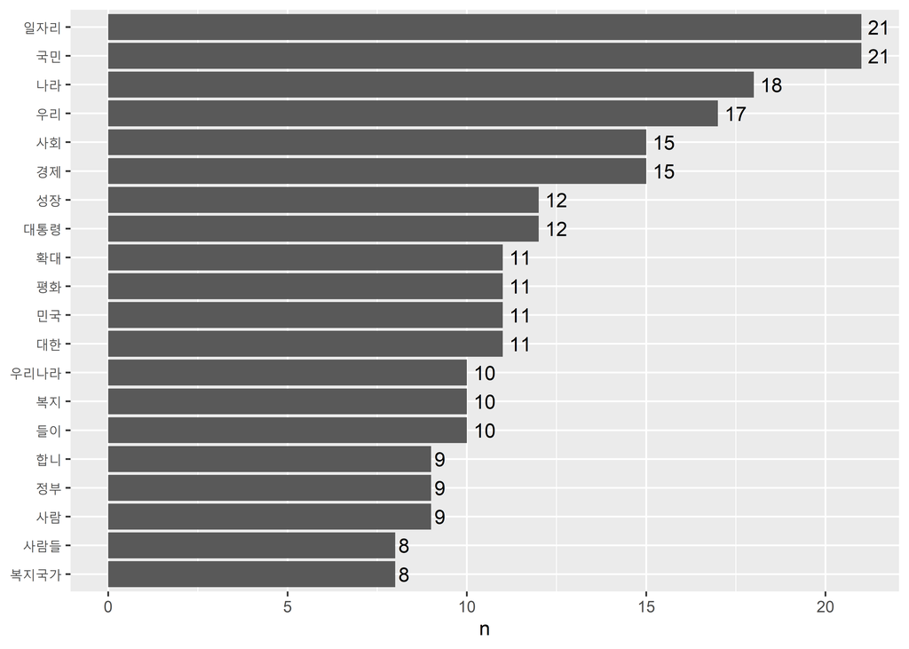

##### 띄어쓰기 기준 추출

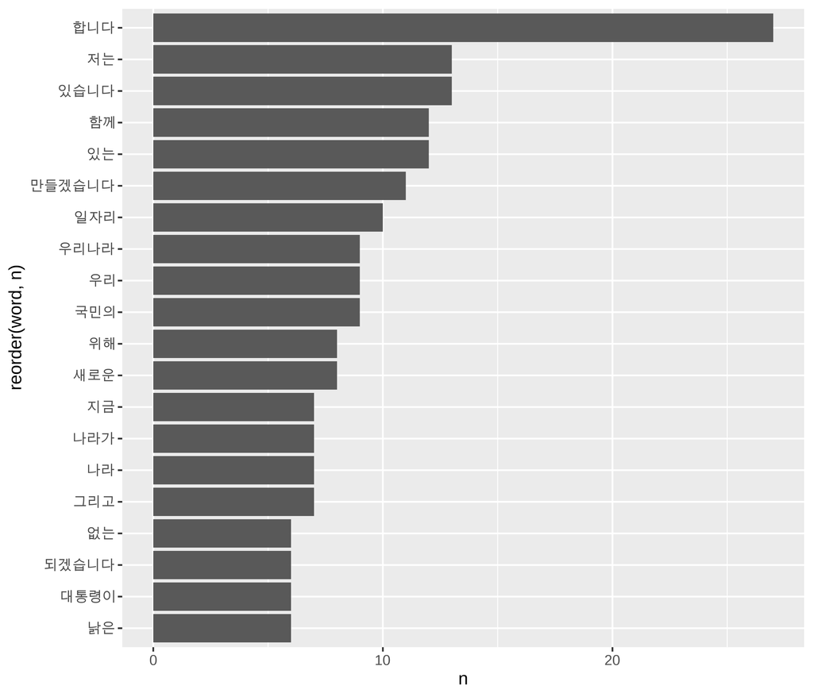

##### 워드 클라우드 만들기

[figure not shown]

```r
# 폰트 설정
library(showtext)
font_add_google(name = "Black Han Sans", family = "blackhansans")
showtext_auto()

library(ggwordcloud)
ggplot(word_noun, aes(label = word, size = n, col = n)) +
  geom_text_wordcloud(seed = 1234, family = "blackhansans") +
  scale_radius(limits = c(3, NA),
               range = c(3, 15)) +
  scale_color_gradient(low = "#66aaf2", high = "#004EA1") +
  theme_minimal()
```

## 특정 단어가 사용된 문장 살펴보기

- 고빈도 단어 사용된 문장 확인하기
- 글쓴이가 어떤 의미로 단어를 사용했는지 이해할 수 있음

##### 문장 기준으로 토큰화하기

- 원문 `raw_moon`을 문장 기준으로 토큰화

```r
sentences_moon <- raw_moon %>%
  str_squish() %>%
  as_tibble() %>%
  unnest_tokens(input = value,
                output = sentence,
                token = "sentences") #<<

sentences_moon
```

문장으로 토큰화할 때는 마침표가 문장의 기준점이 되므로 특수 문자 제거 X

```
## # A tibble: 207 x 1
##    sentence
##    <chr>
##  1 정권교체 하겠습니다!
##  2 정치교체 하겠습니다!
##  3 시대교체 하겠습니다!
##  4 ‘불비불명(不飛不鳴)’이라는 고사가 있습니다.
##  5 남쪽 언덕 나뭇가지에 앉아, 3년 동안 날지도 울지도 않는 새.
##  6 그러나 그 새는 한번 날면 하늘 끝까지 날고, 한번 울면 천지를 뒤흔듭니다.
##  7 그 동안 정치와 거리를 둬 왔습니다.
##  8 그러나 암울한 시대가 저를 정치로 불러냈습니다.
##  9 더 이상 남쪽 나뭇가지에 머무를 수 없었습니다.
## 10 이제 저는 국민과 함께 높이 날고 크게 울겠습니다.
## # ... with 197 more rows
```

#### 특정 단어가 사용된 문장 추출하기

##### 특정 단어가 들어 있는지 확인하기 - `str_detect()`

- 단어가 문장에 있으면 `TRUE`, 그렇지 않으면 `FALSE` 반환

```r
str_detect("치킨은 맛있다", "치킨")
```

```
## [1] TRUE
```

```r
str_detect("치킨은 맛있다", "피자")
```

```
## [1] FALSE
```

##### 특정 단어가 사용된 문장 추출하기

```r
sentences_moon %>%
  filter(str_detect(sentence, "국민"))
```

```
## # A tibble: 19 x 1
##    sentence
##    <chr>
##  1 이제 저는 국민과 함께 높이 날고 크게 울겠습니다.
##  2 오늘 저는 제18대 대통령선거 출마를 국민 앞에 엄숙히 선언합니다.
##  3 존경하는 국민 여러분!
##  4 국민이 모두 아픕니다.
##  5 국민 한 사람 한 사람이 모두 아픕니다.
##  6 국민들에게 희망을 주는 정치가 절실하게 필요합니다.
##  7 국민의 뜻이 대통령의 길입니다.
##  8 저는 대선출마를 결심하고 국민 여러분께 출마선언문을 함께 쓰자고 제안 드렸습~
##  9 시민의 한숨과 눈물을 닦아주지 못하는 정치가 있었고, 오히려 국민의 걱정거리가~
## 10 상식이 통하는 사회, 권한과 책임이 비례하는 사회, 다름을 인정하는 세상, 개천~
## 11 그러나 거창하게만 들리는 이 국가비전 역시 국민의 마음속에 있었습니다.
## 12 더욱 낮아지고 겸손해져서 국민의 마음속으로 들어가라.
## 13 국민들이 제게 준 가르침입니다.
## 14 국민의 뜻에서 대통령의 길을 찾겠습니다.
## 15 문화혁신을 통해 모든 국민의 창조성을 높이고 이를 통해 기술혁신과 신산업 형성~
## 16 이렇게 하면 국민의 살림이 서서히 나아질 것이며 5년 뒤에는 큰 성과가 나타날 ~
## 17 이명박 정부의 방해에도 불구하고 끝내 국민이 지켜준 세종시, 혁신도시를 지방 ~
## 18 존경하는 국민 여러분!
## 19 국민의 마음에서 길을 찾는 우리나라 대통령이 되겠습니다.
```

##### 특정 단어가 사용된 문장 추출하기

```r
sentences_moon %>%
  filter(str_detect(sentence, "일자리"))
```

```
## # A tibble: 18 x 1
##    sentence
##    <chr>
##  1 빚 갚기 힘들어서, 아이 키우기 힘들어서, 일자리가 보이지 않아서 아픕니다.
##  2 상생과 평화의 대한민국은 공평과 정의에 바탕을 두고, 성장의 과실을 함께 누리~
##  3 복지의 확대를 통해 보육, 교육, 의료, 요양 등 사회서비스 부문에 수많은 일자리~
##  4 결국 복지국가로 가는 길은 사람에 대한 투자, 일자리 창출, 자영업 고통 경감, ~
##  5 ‘일자리 정부’로 ‘일자리 혁명’을 이루겠습니다.
##  6 복지의 확대와 함께 저는 강력한 ‘일자리 혁명’을 이루고자 합니다.
##  7 지금 너무나 많은 젊은이들과 실업자, 비정규직 종사자, 근로능력이 있는 고령자~
##  8 좋은 일자리 창출을 위해 비정규직의 정규직 전환 촉진, 비정규직에 대한 차별철~
##  9 또한 정보통신 산업, 바이오산업, 나노 산업, 신재생에너지 산업, 문화산업과 콘~
## 10 그리고 앞에서 말한 보육, 교육, 의료, 복지 등 사회서비스 부문은 무궁무진한 잠~
## 11 일자리 없는 곳에서 희망을 찾을 수 없습니다.
## 12 지방 일자리에 대해 특별한 노력을 기울이겠습니다.
## 13 지역균형발전은 곧 산업 균형, 일자리 균형이 목표입니다.
## 14 이명박 정부의 방해에도 불구하고 끝내 국민이 지켜준 세종시, 혁신도시를 지방 ~
## 15 이 모든 정책의 실효성을 담보하기 위해 대통령이 되면 저는 가장 먼저 대통령 직~
## 16 저는 먼 훗날 ‘일자리 혁명을 일으킨 대통령’으로 평가받기를 희망합니다.
## 17 또한 좋은 일자리와 산업혁신을 위해서는 평생학습체제가 뒷받침되어야 합니다.
## 18 노인 일자리를 늘리고, 특히 그 연륜과 경험을 지역사회에 활용할 수 있는 방안도~
```

tibble 구조는 텍스트가 길면 Console 창 크기에 맞춰 일부만 출력함

- 모든 내용 출력 하려면: `%>% data.frame()`
- 왼쪽 정렬 출력 하려면: `%>% print.data.frame(right = F)`

### 정리하기

##### 1. 명사 추출하기

```r
# 명사 기준 토큰화
word_noun <- moon %>%
  unnest_tokens(input = value,
                output = word,
                token = extractNoun)
```

##### 2. 특정 단어가 사용된 문장 살펴보기

```r
# 문장 기준 토큰화
sentences_moon <- raw_moon %>%
  str_squish() %>%
  as_tibble() %>%
  unnest_tokens(input = value,
                output = sentence,
                token = "sentences")

# 특정 단어가 사용된 문장 추출
sentences_moon %>%
  filter(str_detect(sentence, "국민"))
```